# DATA608 - Module 1 R Notebook, Author - Peter Gatica

```r
library(tidyverse)
library(tidytext)
library(ggplot2)
library(gcookbook)
library(dplyr)
```

**Principles of Data Visualization and Introduction to ggplot2**

I have provided you with data about the 5,000 fastest growing companies in the US, as compiled by Inc. magazine. lets read this in:

```r
inc <- read.csv("https://raw.githubusercontent.com/charleyferrari/CUNY_DATA_608/master/module1/Data/inc5000_data.csv", header= TRUE)
```

And lets preview this data:

```r
head(inc)
```

|  | Rank | Name | Growth_Rate | Revenue | Industry | Employees | City | State |
| --- | --- | --- | --- | --- | --- | --- | --- | --- |
| 1 | 1 | Fuhu | 421.48 | 1.179e+08 | Consumer Products & Services | 104 | El Segundo | CA |
| 2 | 2 | FederalConference.com | 248.31 | 4.960e+07 | Government Services | 51 | Dumfries | VA |
| 3 | 3 | The HCI Group | 245.45 | 2.550e+07 | Health | 132 | Jacksonville | FL |
| 4 | 4 | Bridger | 233.08 | 1.900e+09 | Energy | 50 | Addison | TX |
| 5 | 5 | DataXu | 213.37 | 8.700e+07 | Advertising & Marketing | 220 | Boston | MA |
| 6 | 6 | MileStone Community Builders | 179.38 | 4.570e+07 | Real Estate | 63 | Austin | TX |

```r
summary(inc)
```

```
      Rank          Name            Growth_Rate         Revenue            Industry           Employees           City
 Min.   :   1   Length:5001        Min.   :  0.340   Min.   :2.000e+06   Length:5001        Min.   :    1.0   Length:5001
 1st Qu.:1252   Class :character   1st Qu.:  0.770   1st Qu.:5.100e+06   Class :character   1st Qu.:   25.0   Class :character
 Median :2502   Mode  :character   Median :  1.420   Median :1.090e+07   Mode  :character   Median :   53.0   Mode  :character
 Mean   :2502                      Mean   :  4.612   Mean   :4.822e+07                      Mean   :  232.7
 3rd Qu.:3751                      3rd Qu.:  3.290   3rd Qu.:2.860e+07                      3rd Qu.:  132.0
 Max.   :5000                      Max.   :421.480   Max.   :1.010e+10                      Max.   :66803.0
                                                                                            NA's   :12
    State
 Length:5001
 Class :character
 Mode  :character
```

Think a bit on what these summaries mean. Use the space below to add some more relevant non-visual exploratory information you think helps you understand this data:

### Taking a look at the summary of the data and I immediately notice the maximum number of employees of a company and the minmum number. This is a very large gap between the maximum and the minimum and I cannot help but wonder what affect that may have on the average number of employees per company.

## Question 1

Create a graph that shows the distribution of companies in the dataset by State (ie how many are in each state). There are a lot of States, so consider which axis you should use. This visualization is ultimately going to be consumed on a ‘portrait’ oriented screen (ie taller than wide), which should further guide your layout choices.

```r
# Count the number of companies by state
inc_agg_by_state <- aggregate(inc$Name, by=list(inc$State), FUN=length)
# rename columns
names(inc_agg_by_state) <- c("State", "Count")
# inc_agg_by_state
```

```r
head(inc_agg_by_state[with(inc_agg_by_state, order(-Count)),],5) # List in order by the total number of companies in each state for the first 5 companies
```

|  | State | Count |
| --- | --- | --- |
| 5 | CA | 701 |
| 45 | TX | 387 |
| 35 | NY | 311 |
| 47 | VA | 283 |
| 10 | FL | 282 |

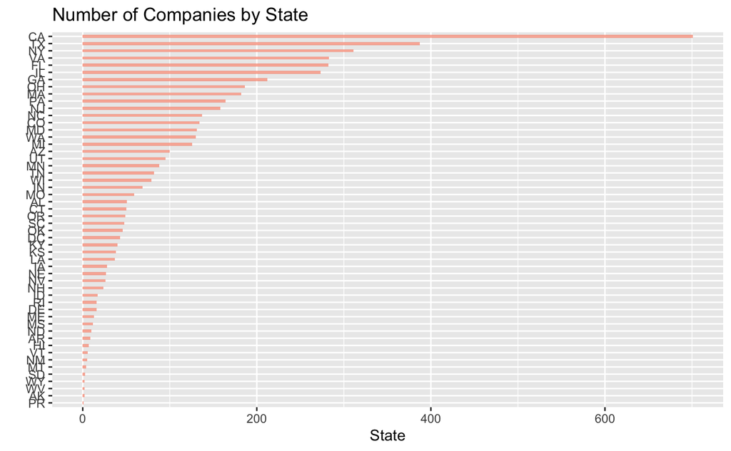

```r
inc_agg_by_state %>%
#  top_n(10) %>%  #extract top 10
    ggplot(aes(fct_reorder(`State`,`Count`), `Count`))+
      geom_bar(stat="identity", fill="#f68060", alpha=.6, width=.4) +
      coord_flip() +
      xlab("") +
      ylab("State")+
      ggtitle("Number of Companies by State")
```

## Quesiton 2

Lets dig in on the state with the 3rd most companies in the data set. Imagine you work for the state and are interested in how many people are employed by companies in different industries. Create a plot that shows the average and/or median employment by industry for companies in this state (only use cases with full data, use R’s `complete.cases()` function.) In addition to this, your graph should show how variable the ranges are, and you should deal with outliers.

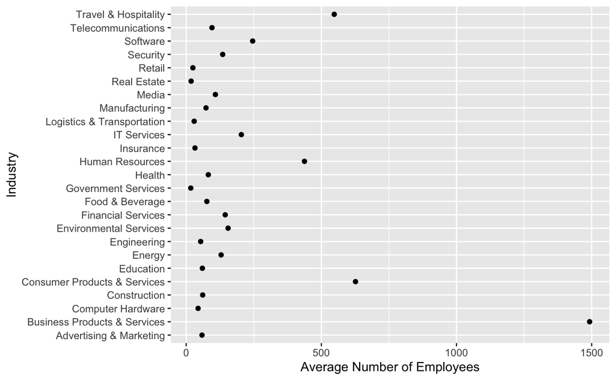

```r
# Answer Question 2 here
# Get the cases with full data in the state with the 3rd most companies
inc_comp_cases_ny <- inc[complete.cases(inc), ] %>%
  filter(State == 'NY')

# Get the average/mean of employment by Industry
inc_ny <- aggregate(Employees ~ Industry, data=inc_comp_cases_ny, FUN=mean)
names(inc_ny) <- c("Industry", "AvgNumEmps")

# Create a scatter plot to show the average and/or median employment by industry for companies in this state
ggplot(inc_ny, aes(x = AvgNumEmps, y = Industry)) +
  xlab("Average Number of Employees") +
  geom_point()
```

```r
head(inc_ny[with(inc_ny, order(-AvgNumEmps)),],5) # List in order by the total number of companies in the state
```

|  | Industry | AvgNumEmps |
| --- | --- | --- |
| 2 | Business Products & Services | 1492.4615 |
| 5 | Consumer Products & Services | 626.2941 |
| 25 | Travel & Hospitality | 547.7143 |
| 14 | Human Resources | 437.5455 |
| 23 | Software | 245.9231 |

### Also notice that the number of employees for the largest company is over 3 times the number of the next larger company in the New York. This will definitely affect the average number of employees which can in turn can skew other averages. I will exclude the Sutherland Global Services company to see what kind of affect it will have and will consider it an outlier.

```r
head(inc_comp_cases_ny[with(inc_comp_cases_ny, order(-Employees)),c("Rank","Name","Industry","Employees")],5)
```

|  | Rank | Name | Industry | Employees |
| --- | --- | --- | --- | --- |
| 274 | 4577 | Sutherland Global Services | Business Products & Services | 32000 |
| 307 | 4936 | Coty | Consumer Products & Services | 10000 |
| 287 | 4716 | Westcon Group | IT Services | 3000 |
| 228 | 3899 | Denihan Hospitality Group | Travel & Hospitality | 2280 |
| 254 | 4363 | TransPerfect | Business Products & Services | 2218 |

```r
# Filter the Sutherland company
inc_ny_emp_no_out <- inc_comp_cases_ny %>%
  filter(Employees < 10001)

# Recalculate the average/mean of employment by Industry
inc_ny_emp_no_out <- aggregate(Employees ~ Industry, data=inc_ny_emp_no_out, FUN=mean)
names(inc_ny_emp_no_out) <- c("Industry", "AvgNumEmps")
inc_ny_emp_no_out[with(inc_ny_emp_no_out, order(-AvgNumEmps)),] # List in order by the total number of companies in the state
```

|  | Industry | AvgNumEmps |
| --- | --- | --- |
| 5 | Consumer Products & Services | 626.29412 |
| 25 | Travel & Hospitality | 547.71429 |
| 14 | Human Resources | 437.54545 |
| 2 | Business Products & Services | 272.16000 |
| 23 | Software | 245.92308 |
| 16 | IT Services | 204.09302 |
| 9 | Environmental Services | 155.00000 |
| 10 | Financial Services | 144.30769 |
| 22 | Security | 135.00000 |
| 7 | Energy | 129.20000 |

[output cut: 15 more lines]

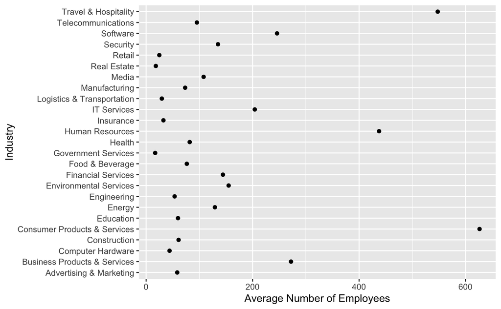

```r
ggplot(inc_ny_emp_no_out, aes(x = AvgNumEmps, y = Industry)) +
    xlab("Average Number of Employees") +
  geom_point()
```

```r
summary(inc_ny_emp_no_out)
```

```
   Industry           AvgNumEmps
 Length:25          Min.   : 17.00
 Class :character   1st Qu.: 53.50
 Mode  :character   Median : 81.85
                    Mean   :149.24
                    3rd Qu.:155.00
                    Max.   :626.29
```

### As you can see by the scatterplot and the summary that excluding the Sutherland company shows a more accurate measure of the average number of employees by company across all industires for the state of New York at 149.24 number of employees. I believe that considering Sutherland company as an outlier is the right thing to do.

## Question 3

Now imagine you work for an investor and want to see which industries generate the most revenue per employee. Create a chart that makes this information clear. Once again, the distribution per industry should be shown.

```r
# Answer Question 3 here
# Get the average/mean of employment by Industry
inc_rev_emps <- aggregate(cbind(Revenue, Employees) ~ Industry, data=inc, FUN=sum)

inc_rev_by_emp <- group_by(inc_rev_emps, Industry, Revenue / Employees)

# rename columns
names(inc_rev_by_emp) <- c("Industry", "Revenue", "Employees" , "RevenuePerEmployee")
inc_rev_by_emp
```

| Industry | Revenue | Employees | RevenuePerEmployee |
| --- | --- | --- | --- |
| Advertising & Marketing | 7785000000 | 39731 | 195942.71 |
| Business Products & Services | 26345900000 | 117357 | 224493.64 |
| Computer Hardware | 11885700000 | 9714 | 1223563.93 |
| Construction | 13174300000 | 29099 | 452740.64 |
| Consumer Products & Services | 14956400000 | 45464 | 328972.37 |
| Education | 1139300000 | 7685 | 148249.84 |
| Energy | 13771600000 | 26437 | 520921.44 |
| Engineering | 2532500000 | 20435 | 123929.53 |
| Environmental Services | 2638800000 | 10155 | 259852.29 |
| Financial Services | 13150900000 | 47693 | 275740.67 |

[output cut: 15 more lines]

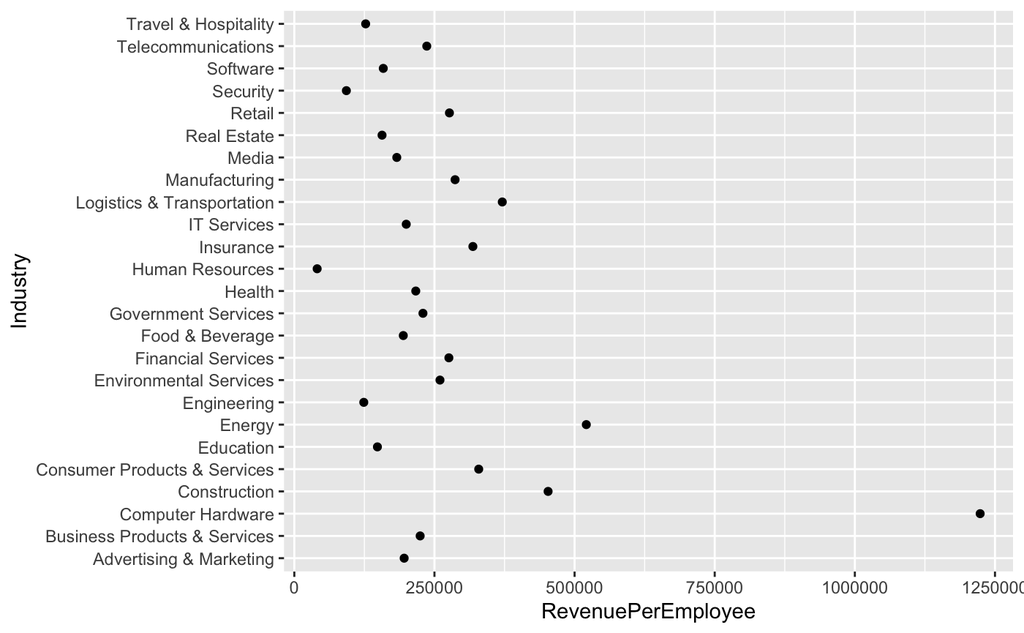

```r
ggplot(inc_rev_by_emp, aes(x = RevenuePerEmployee, y = Industry)) +
  geom_point()
```

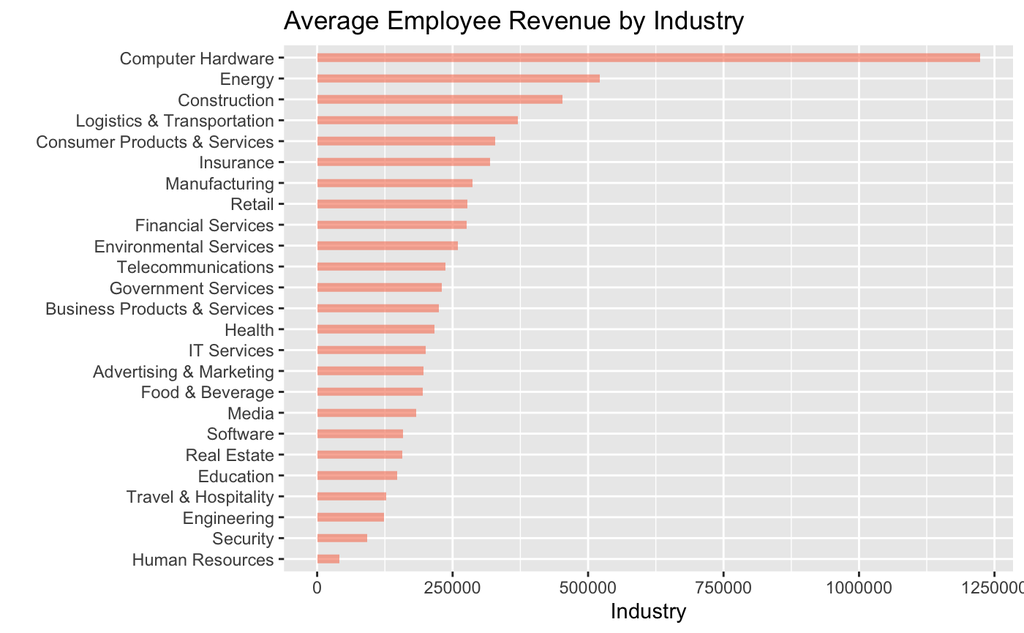

```r
inc_rev_by_emp %>%
    ggplot(aes(fct_reorder(`Industry`,`RevenuePerEmployee`), `RevenuePerEmployee`))+
      geom_bar(stat="identity", fill="#f68060", alpha=.6, width=.4) +
      coord_flip() +
      xlab("") +
      ylab("Industry")+
      ggtitle("Average Employee Revenue by Industry")
```

### In conclusion, as an investor I would most likely invest my money in the Computer Hardware industry if I was making that decision based on the average revenue generated per employee.